# Data Wrangling with tidyr

- Describe the concept of a wide and a long table format and for which purpose those formats are useful.
- Describe the roles of variable names and their associated values when a table is reshaped.
- Reshape a dataframe from long to wide format and back with the `pivot_wider` and `pivot_longer` commands from the **`tidyr`** package.
- Export a dataframe to a csv file.
- How can I reformat a data frame to meet my needs?

**`dplyr`** pairs nicely with **`tidyr`** which enables you to swiftly convert between different data formats (long vs. wide) for plotting and analysis. To learn more about **`tidyr`** after the workshop, you may want to check out this [handy data tidying with **`tidyr`** cheatsheet](https://raw.githubusercontent.com/rstudio/cheatsheets/main/tidyr.pdf).

To make sure everyone will use the same dataset for this lesson, we’ll read again the SAFI dataset that we downloaded earlier.

```r
## load the tidyverse
library(tidyverse)
library(here)

interviews <- read_csv(here("data", "SAFI_clean.csv"), na = "NULL")

## inspect the data
interviews

## preview the data
# view(interviews)
```

## Reshaping with pivot_wider() and pivot_longer()

There are essentially three rules that define a “tidy” dataset:

1. Each variable has its own column
2. Each observation has its own row
3. Each value must have its own cell

In this section we will explore how these rules are linked to the different data formats researchers are often interested in: “wide” and “long”. This tutorial will help you efficiently transform your data shape regardless of original format. First we will explore qualities of the `interviews` data and how they relate to these different types of data formats.

### Long and wide data formats

In the `interviews` data, each row contains the values of variables associated with each record collected (each interview in the villages). It is stated that the `key_ID` was “added to provide a unique Id for each observation” and the `instanceID` “does this as well but it is not as convenient to use.”

Once we have established that `key_ID` and `instanceID` are both unique we can use either variable as an identifier corresponding to the 131 interview records.

```r
interviews %>%
  select(key_ID) %>%
  distinct() %>%
  count()
```

```
## # A tibble: 1 × 1
##       n
##   <int>
## 1   131
```

```r
interviews %>%
  select(instanceID) %>%
  distinct() %>%
  count()
```

```
## # A tibble: 1 × 1
##       n
##   <int>
## 1   131
```

As seen in the code below, for each interview date in each village no `instanceID`s are the same. Thus, this format is what is called a “long” data format, where each observation occupies only one row in the dataframe.

```r
interviews %>%
  filter(village == "Chirodzo") %>%
  select(key_ID, village, interview_date, instanceID) %>%
  sample_n(size = 10)
```

```
## # A tibble: 10 × 4
##    key_ID village  interview_date      instanceID
##     <dbl> <chr>    <dttm>              <chr>
##  1     51 Chirodzo 2016-11-16 00:00:00 uuid:18ac8e77-bdaf-47ab-85a2-e4c947c9d3ce
##  2      8 Chirodzo 2016-11-16 00:00:00 uuid:d6cee930-7be1-4fd9-88c0-82a08f90fb5a
##  3     53 Chirodzo 2016-11-16 00:00:00 uuid:cc7f75c5-d13e-43f3-97e5-4f4c03cb4b12
##  4     70 Chirodzo 2016-11-16 00:00:00 uuid:1feb0108-4599-4bf9-8a07-1f5e66a50a0a
##  5     10 Chirodzo 2016-12-16 00:00:00 uuid:8f4e49bc-da81-4356-ae34-e0d794a23721
##  6    200 Chirodzo 2017-06-04 00:00:00 uuid:aa77a0d7-7142-41c8-b494-483a5b68d8a7
##  7    199 Chirodzo 2017-06-04 00:00:00 uuid:ffc83162-ff24-4a87-8709-eff17abc0b3b
##  8     37 Chirodzo 2016-11-17 00:00:00 uuid:408c6c93-d723-45ef-8dee-1b1bd3fe20cd
##  9     58 Chirodzo 2016-11-16 00:00:00 uuid:a7a3451f-cd0d-4027-82d9-8dcd1234fcca
## 10     44 Chirodzo 2016-11-17 00:00:00 uuid:f9fadf44-d040-4fca-86c1-2835f79c4952
```

We notice that the layout or format of the `interviews` data is in a format that adheres to rules 1-3, where

- each column is a variable
- each row is an observation
- each value has its own cell

This is called a “long” data format. But, we notice that each column represents a different variable. In the “longest” data format there would only be three columns, one for the id variable, one for the observed variable, and one for the observed value (of that variable). This data format is quite unsightly and difficult to work with, so you will rarely see it in use.

Alternatively, in a “wide” data format we see modifications to rule 1, where each column no longer represents a single variable. Instead, columns can represent different levels/values of a variable. For instance, in some data you encounter the researchers may have chosen for every survey date to be a different column.

These may sound like dramatically different data layouts, but there are some tools that make transitions between these layouts much simpler than you might think! The gif below shows how these two formats relate to each other, and gives you an idea of how we can use R to shift from one format to the other.

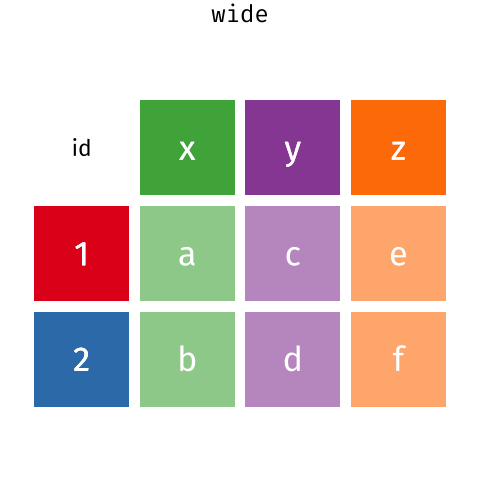

Long and wide dataframe layouts mainly affect readability. You may find that visually you may prefer the “wide” format, since you can see more of the data on the screen. However, all of the R functions we have used thus far expect for your data to be in a “long” data format. This is because the long format is more machine readable and is closer to the formatting of databases.

### Questions which warrant different data formats

In interviews, each row contains the values of variables associated with each record (the unit), values such as the village of the respondent, the number of household members, or the type of wall their house had. This format allows for us to make comparisons across individual surveys, but what if we wanted to look at differences in households grouped by different types of items owned?

To facilitate this comparison we would need to create a new table where each row (the unit) was comprised of values of variables associated with items owned (i.e., `items_owned`). In practical terms this means the values of the items in `items_owned` (e.g. bicycle, radio, table, etc.) would become the names of column variables and the cells would contain values of `TRUE` or `FALSE`, for whether that household had that item.

Once we we’ve created this new table, we can explore the relationship within and between villages. The key point here is that we are still following a tidy data structure, but we have **reshaped** the data according to the observations of interest.

Alternatively, if the interview dates were spread across multiple columns, and we were interested in visualizing, within each village, how irrigation conflicts have changed over time. This would require for the interview date to be included in a single column rather than spread across multiple columns. Thus, we would need to transform the column names into values of a variable.

We can do both of these transformations with two `tidyr` functions, `pivot_wider()` and `pivot_longer()`.

## Pivoting wider

`pivot_wider()` takes three principal arguments:

1. the data
2. the *names_from* column variable whose values will become new column names.
3. the *values_from* column variable whose values will fill the new column variables.

Further arguments include `values_fill` which, if set, fills in missing values with the value provided.

Let’s use `pivot_wider()` to transform interviews to create new columns for each item owned by a household. There are a couple of new concepts in this transformation, so let’s walk through it line by line. First we create a new object (`interviews_items_owned`) based on the `interviews` data frame.

```r
interviews_items_owned <- interviews %>%
```

Then we will actually need to make our data frame longer, because we have multiple items in a single cell. We will use a new function, `separate_longer_delim()`, from the **`tidyr`** package to separate the values of `items_owned` based on the presence of semi-colons (`;`). The values of this variable were multiple items separated by semi-colons, so this action creates a row for each item listed in a household’s possession. Thus, we end up with a long format version of the dataset, with multiple rows for each respondent. For example, if a respondent has a television and a solar panel, that respondent will now have two rows, one with “television” and the other with “solar panel” in the `items_owned` column.

```r
separate_longer_delim(items_owned, delim = ";") %>%
```

After this transformation, you may notice that the `items_owned` column contains `NA` values. This is because some of the respondents did not own any of the items in the interviewer’s list. We can use the `replace_na()` function to change these `NA` values to something more meaningful. The `replace_na()` function expects for you to give it a `list()` of columns that you would like to replace the `NA` values in, and the value that you would like to replace the `NA`s. This ends up looking like this:

```r
replace_na(list(items_owned = "no_listed_items")) %>%
```

Next, we create a new variable named `items_owned_logical`, which has one value (`TRUE`) for every row. This makes sense, since each item in every row was owned by that household. We are constructing this variable so that when we spread the `items_owned` across multiple columns, we can fill the values of those columns with logical values describing whether the household did (`TRUE`) or did not (`FALSE`) own that particular item.

```r
mutate(items_owned_logical = TRUE) %>%
```

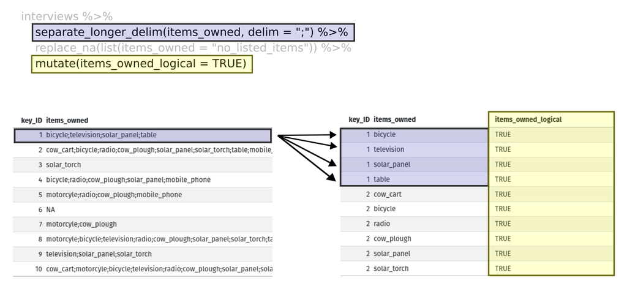

At this point, we can also count the number of items owned by each household, which is equivalent to the number of rows per `key_ID`. We can do this with a `group_by()` and `mutate()` pipeline that works similar to `group_by()` and `summarize()` discussed in the previous episode but instead of creating a summary table, we will add another column called `number_items`. We use the `n()` function to count the number of rows within each group. However, there is one difficulty we need to take into account, namely those households that did not list any items. These households now have `"no_listed_items"` under `items_owned`. We do not want to count this as an item but instead show zero items. We can accomplish this using **`dplyr`’s** `if_else()` function that evaluates a condition and returns one value if true and another if false. Here, if the `items_owned` column is `"no_listed_items"`, then a 0 is returned, otherwise, the number of rows per group is returned using `n()`.

```r
group_by(key_ID) %>%
  mutate(number_items = if_else(items_owned == "no_listed_items", 0, n())) %>%
```

Lastly, we use `pivot_wider()` to switch from long format to wide format. This creates a new column for each of the unique values in the `items_owned` column, and fills those columns with the values of `items_owned_logical`. We also declare that for items that are missing, we want to fill those cells with the value of `FALSE` instead of `NA`.

```r
pivot_wider(names_from = items_owned,
            values_from = items_owned_logical,
            values_fill = list(items_owned_logical = FALSE))
```

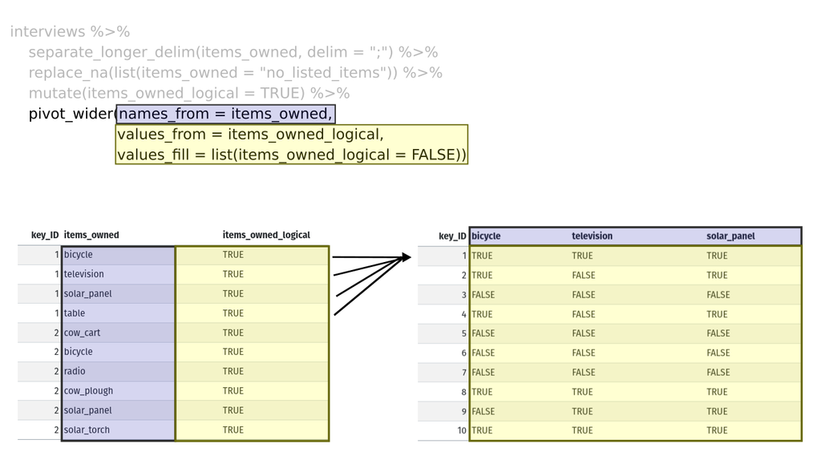

Combining the above steps, the chunk looks like this. Note that two new columns are created within the same `mutate()` call.

```r
interviews_items_owned <- interviews %>%
  separate_longer_delim(items_owned, delim = ";") %>%
  replace_na(list(items_owned = "no_listed_items")) %>%
  group_by(key_ID) %>%
  mutate(items_owned_logical = TRUE,
         number_items = if_else(items_owned == "no_listed_items", 0, n())) %>%
  pivot_wider(names_from = items_owned,
              values_from = items_owned_logical,
              values_fill = list(items_owned_logical = FALSE))
```

This format of the data allows us to do interesting things, like make a table showing the number of respondents in each village who owned a particular item:

```r
interviews_items_owned %>%
  filter(bicycle) %>%
  group_by(village) %>%
  count(bicycle)
```

```
## # A tibble: 3 × 3
## # Groups:   village [3]
##   village  bicycle     n
##   <chr>    <lgl>   <int>
## 1 Chirodzo TRUE       17
## 2 God      TRUE       23
## 3 Ruaca    TRUE       20
```

Or below we calculate the average number of items from the list owned by respondents in each village using the `number_items` column we created to count the items listed by each household.

```r
interviews_items_owned %>%
    group_by(village) %>%
    summarize(mean_items = mean(number_items))
```

```
## # A tibble: 3 × 2
##   village  mean_items
##   <chr>         <dbl>
## 1 Chirodzo       4.54
## 2 God            3.98
## 3 Ruaca          5.57
```

## Exercise

We created `interviews_items_owned` by reshaping the data: first longer and then wider. Replicate this process with the `months_lack_food` column in the `interviews` dataframe. Create a new dataframe with columns for each of the months filled with logical vectors (`TRUE` or `FALSE`) and a summary column called `number_months_lack_food` that calculates the number of months each household reported a lack of food.

Note that if the household did not lack food in the previous 12 months, the value input was “none”.

## Solution

```r
months_lack_food <- interviews %>%
  separate_longer_delim(months_lack_food, delim = ";") %>%
  group_by(key_ID) %>%
  mutate(months_lack_food_logical = TRUE,
         number_months_lack_food = if_else(months_lack_food == "none", 0, n())) %>%
  pivot_wider(names_from = months_lack_food,
              values_from = months_lack_food_logical,
              values_fill = list(months_lack_food_logical = FALSE))
```

## Pivoting longer

The opposing situation could occur if we had been provided with data in the form of `interviews_wide`, where the items owned are column names, but we wish to treat them as values of an `items_owned` variable instead.

`pivot_longer()` takes four principal arguments:

1. the data
2. *cols* are the names of the columns we use to fill the a new values variable (or to drop).
3. the *names_to* column variable we wish to create from the *cols* provided.
4. the *values_to* column variable we wish to create and fill with values associated with the *cols* provided.

```r
interviews_long <- interviews_items_owned %>%
  pivot_longer(cols = bicycle:car,
               names_to = "items_owned",
               values_to = "items_owned_logical")
```

View both `interviews_long` and `interviews_items_owned` and compare their structure.

## Exercise

We created some summary tables on `interviews_items_owned` using `count` and `summarise`. We can create the same tables on `interviews_long`, but this will require a different process.

Make a table showing the number of respondents in each village who owned a particular item, and include all items. The difference between this format and the wide format is that you can now `count` all the items using the `items_owned` variable.

## Solution

```r
interviews_long %>%
  filter(items_owned_logical) %>%
  group_by(village) %>%
  count(items_owned)
```

```
## # A tibble: 47 × 3
## # Groups:   village [3]
##    village  items_owned         n
##    <chr>    <chr>           <int>
##  1 Chirodzo bicycle            17
##  2 Chirodzo computer            2
##  3 Chirodzo cow_cart            6
##  4 Chirodzo cow_plough         20
##  5 Chirodzo electricity         1
##  6 Chirodzo fridge              1
##  7 Chirodzo lorry               1
##  8 Chirodzo mobile_phone       25
##  9 Chirodzo motorcyle          13
## 10 Chirodzo no_listed_items     3
## # ℹ 37 more rows
```

## Applying what we learned to clean our data

Now we have simultaneously learned about `pivot_longer()` and `pivot_wider()`, and fixed a problem in the way our data is structured. In this dataset, we have another column that stores multiple values in a single cell. Some of the cells in the `months_lack_food` column contain multiple months which, as before, are separated by semi-colons (`;`).

To create a data frame where each of the columns contain only one value per cell, we can repeat the steps we applied to `items_owned` and apply them to `months_lack_food`. Since we will be using this data frame for the next episode, we will call it `interviews_plotting`.

```r
## Plotting data ##
interviews_plotting <- interviews %>%
  ## pivot wider by items_owned
  separate_longer_delim(items_owned, delim = ";") %>%
  replace_na(list(items_owned = "no_listed_items")) %>%
  ## Use of grouped mutate to find number of rows
  group_by(key_ID) %>%
  mutate(items_owned_logical = TRUE,
         number_items = if_else(items_owned == "no_listed_items", 0, n())) %>%
  pivot_wider(names_from = items_owned,
              values_from = items_owned_logical,
              values_fill = list(items_owned_logical = FALSE)) %>%
  ## pivot wider by months_lack_food
  separate_longer_delim(months_lack_food, delim = ";") %>%
  mutate(months_lack_food_logical = TRUE,
         number_months_lack_food = if_else(months_lack_food == "none", 0, n())) %>%
  pivot_wider(names_from = months_lack_food,
              values_from = months_lack_food_logical,
              values_fill = list(months_lack_food_logical = FALSE))
```

## Exporting data

Now that you have learned how to use **`dplyr`** and **`tidyr`** to wrangle your raw data, you may want to export these new datasets to share them with your collaborators or for archival purposes.

Similar to the `read_csv()` function used for reading CSV files into R, there is a `write_csv()` function that generates CSV files from data frames.

Before using `write_csv()`, we are going to create a new folder, `data_output`, in our working directory that will store this generated dataset. We don’t want to write generated datasets in the same directory as our raw data. It’s good practice to keep them separate. The `data` folder should only contain the raw, unaltered data, and should be left alone to make sure we don’t delete or modify it. In contrast, our script will generate the contents of the `data_output` directory, so even if the files it contains are deleted, we can always re-generate them.

In preparation for our next lesson on plotting, we created a version of the dataset where each of the columns includes only one data value. Now we can save this data frame to our `data_output` directory.

```r
write_csv(interviews_plotting, file = "data_output/interviews_plotting.csv")
```

- Use the `tidyr` package to change the layout of data frames.
- Use `pivot_wider()` to go from long to wide format.
- Use `pivot_longer()` to go from wide to long format.